# Trabalho Final - MQ

13/12/2020

## Domicílios chefiados por mulheres no Distrito Federal - PDAD 2018

## Objeto da pesquisa

- Utilizando dados da Pesquisa Distrital por Amostra de Domicílios - [PDAD 2018](http://www.codeplan.df.gov.br/pdad-2018/), pretende-se identificar se a infraestrutura urbana difere significativamente para domicílios chefiados por homens e domicílios liderados por mulheres.
- Empregar outras variáveis socioeconômicas para mapear estatísticas descritivas de cor/raça de mulheres chefes de família em relação a outras variáveis socioeconômicas, assim como identificar como varia a infraestrutura urbana por Região Administrativa - RA do DF.

## Contexto

- Nas últimas décadas, cresceu significativamente o número de mulheres que chefiam famílias;
- Ainda assim, nota-se que persiste a lacuna labora em matéria de gênero, pois homens não só obtêm maiores remunerações, como estão mais integrados no mercado formal;
- Dessa forma, o acúmulo de responsabilidades domésticas com a necessidade de se obter renda torna mulheres especialmente vulneráveis à precariedade na provisão de serviços públicos, e, por conseguinte, das deficiências da infraestrutura urbana;
- Nesse sentido, convém investigar se domicílios chefiados por mulheres estão em pior situação infraestutural, quando considerados indicadores urbanos, que residências chefiadas por homens.

## Objetivos

- Criar um Índice Urbano (IND) que capte a qualidade de infraestrutura urbana do local em que se encontram os domicílios;
- Gerar gráficos de estatísticas descritivas que captem a relação entre gênero e variáveis socioeconômicas;
- Gerar gráfico que capte estatísticas descritivas envolvendo o Índice Urbano e as Regiões Administrativas - RAs;
- Descobrir, por meio do teste de hipóteses e da análise de variância, se o gênero e a raça de uma pessoa estão relacionados com a pontuação do IND.

## Método

- Carregar a base dados de domicílio da PDAD 2018 em formato .csv;
- Filtrar as variáveis de infraestrutura que integrarão o Índice Urbano:
  - B141: (2) não tem rede geral CAESB;
  - B182: (2) a sua rua não tem calçada;
  - B185: (2) na sua rua não tem iluminação;
  - B186: (2) na sua rua não tem rede de água pluvial;
  - B191: (1) próximo a sua casa tem entulhos;
  - B192: (1) quando chove a sua rua fica alagada;
  - B193: (1) a sua rua é esburacada;
  - B194: (2) não tem ruas arborizadas;
  - B195: (2) não tem parques e jardins;
  - B196: (2) não tem quadras esportivas.

## Método

- Definir o **Índice Urbano (IND)** como a soma das variáveis selecionadas de infraestrutura das proximidades do domicílio
  - Varia de 0 a 10, quanto maior pior são as condições de urbanização
- Estabelecer as categorias que integram o IND e seus respectivos intervalos
- Carregar a base de dados de moradores da PDAD 2018 em formato .csv;

## Método

- Filtrar variáveis socioeconômicas que integrarão essa segunda base de dados:
  - A01ra: Código da Região Administrativa;
  - A01inFicha: Número da ficha, variável chave para conectar com o banco de dados do domicílio;
  - Condição do morador no domicílio
  - E03: Sexo;
  - E04: Raça;
  - E11: O Sr(a). vive em companhia de cônjuge/companheiro? (2)
  - G13: O Sr(a). tem carteira de trabalho assinada pelo atual empregador?
- Mesclar as duas bases de dados
- Expandir a amostra

## Método

- Gerar gráficos de estatísticas descritivas:
  - Número de mulheres chefes de família por categoria do Índice Urbano
  - Porcentagem de Mulheres chefes de família por raça/cor
  - Porcentagem de mulheres chefes de família por raça/cor que possuem ou não companheiro/a
  - Porcentagem de mulheres chefes de família por raça/cor e tipo de trabalho
  - Índice Urbano por Região Administrativa
- Estimar o intervalo de confiança e representá-lo em um gráfico
- Testar hipóteses

## Gráficos de Estatísticas Descritivas

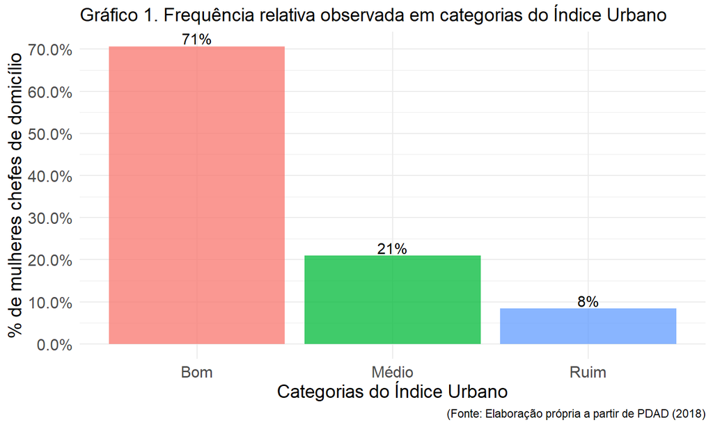

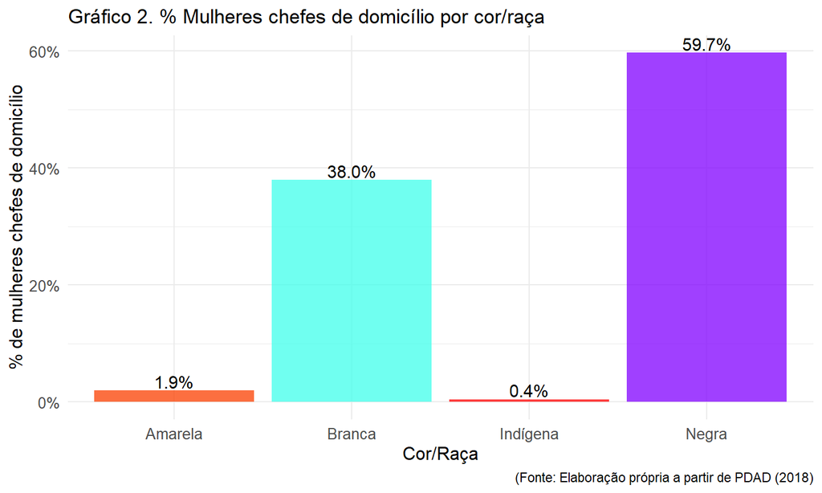

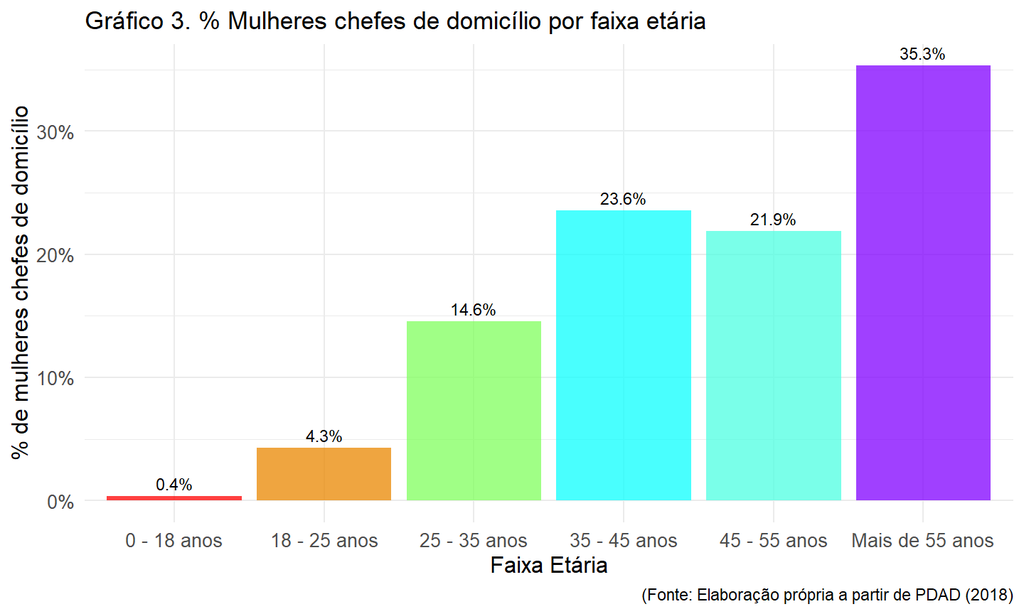

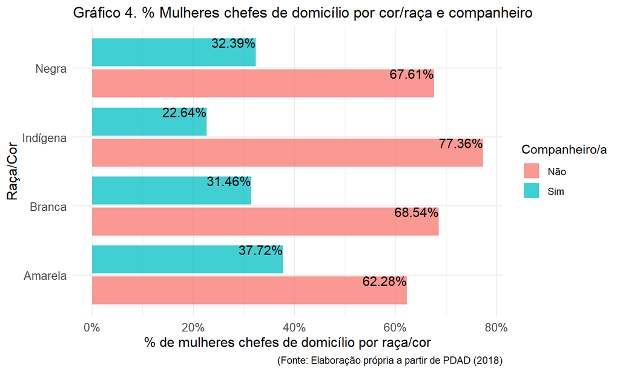

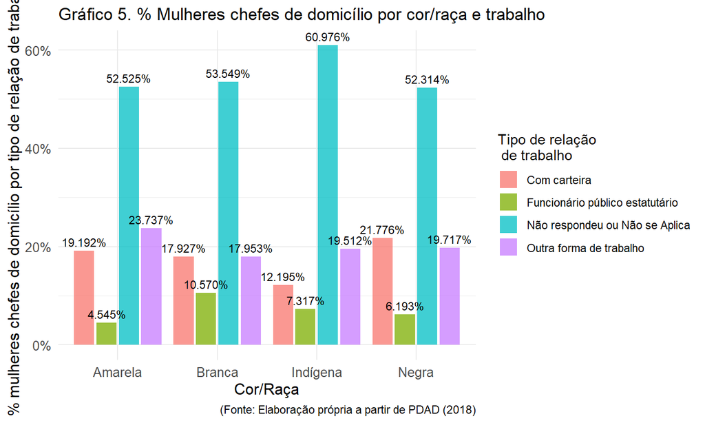

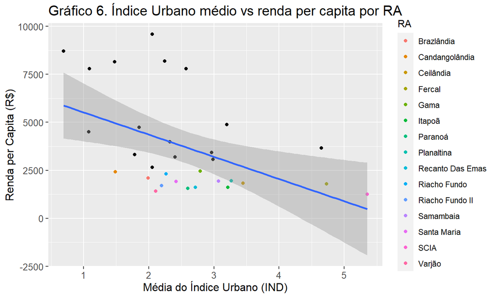

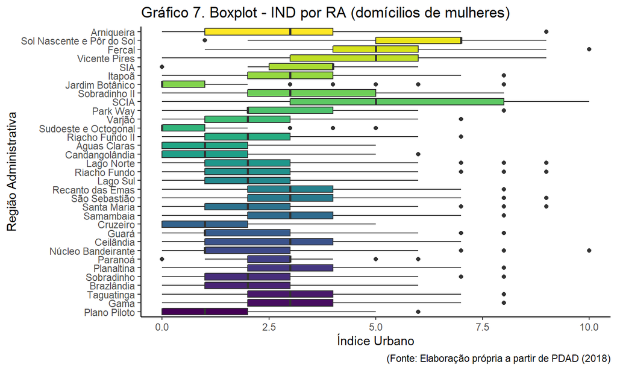

## Inferências Estatísticas

## Intervalo de confiança

- O intervalo de confiança foi estimado a partir da média do Índice Urbano em relação ao gênero dos responsáveis da família.
- O intervalo de confiança para o gênero e Índice Urbano aponta que as mulheres possuem intervalo superior ao dos homens e os intervalos não estão sobrepostos, indicando diferença significativa entre eles.

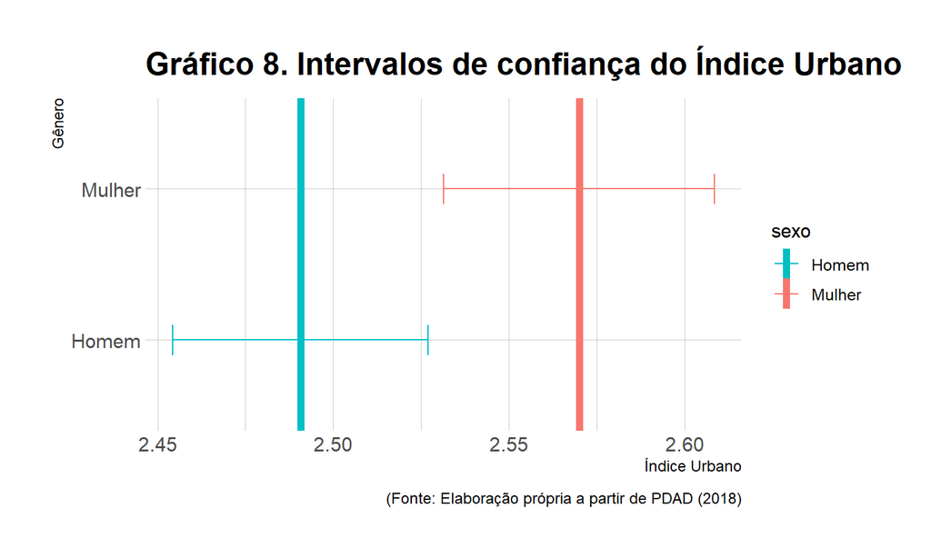

## Teste de Hipótese 1

- Testando se média-IND(feminino) = média-IND(masculino)
- **Pergunta:** O gênero da pessoa responsável pelo domicílio faz diferença nos índices urbanos?
- **Variável dependente**: Índice Urbano
- **Variável independente**: Gênero da pessoa responsável pelo domicílio (Homem ou Mulher)

```
## # A tibble: 1 x 6
##   statistic   t_df p_value alternative lower_ci upper_ci
##       <dbl>  <dbl>   <dbl> <chr>          <dbl>    <dbl>
## 1      2.93 21527. 0.00338 two.sided     0.0263    0.132
```

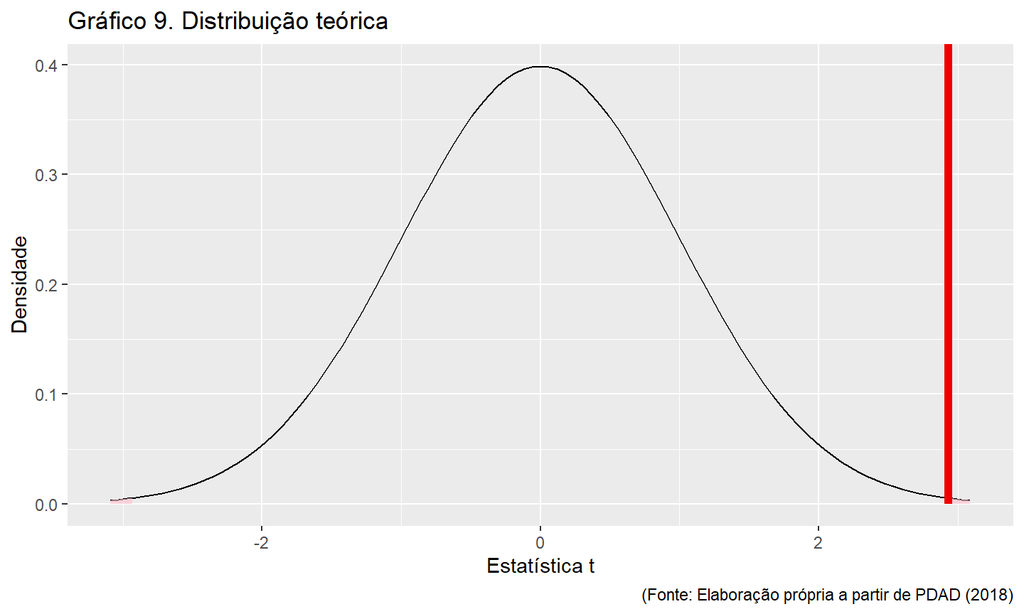

- **Análise do Teste de Hipótese:** rejeita-se Ho, pois o p_value é menor que 0,05 (5%), então pode-se dizer que o índice médio urbano difere em relação ao gênero dos responsáveis pelos domicílios, ao nível de 95% de confiança.

## Teste de Hipótese 2

- **Teste de Análise de Variância (ANOVA):** Teste de média do Índice Urbano por raça.
- **Pergunta:** A raça da pessoa responsável pelo domicílio faz diferença nos índices urbanos?

```
##                Df Sum Sq Mean Sq F value Pr(>F)
## raca            3   1031   343.7   87.02 <2e-16 ***
## Residuals   21904  86505     3.9
## ---
## Signif. codes:  0 '***' 0.001 '**' 0.01 '*' 0.05 '.' 0.1 ' ' 1
```

- **Análise da Análise de Variância:** rejeita-se Ho, pois o p_value é menor que 0,05 (5%), então pode-se dizer que o índice médio urbano difere em relação as raças dos responsáveis pelos domicílios, ao nível de 95% de confiança.

## Conclusões

- O índice de bem-estar para as mulheres chefes de domicílio em relação às suas moradias se mostrou menor do que a dos homens.
- Quando as condições de habitação não são adequadas, os impactos na vida das mulheres são profundos, já que, tradicionalmente, elas exercem o papel social de cuidadoras da casa e da família.
- Por isso, se quisermos de fato promover a igualdade entre homens e mulheres, essas diferenças precisam ser levadas em consideração.

## Referências bibliográficas

- Como fazer valer os direitos das mulheres à moradia? : (https://raquelrolnik.files.wordpress.com/2011/12/guia-mulheres-pt_ok.pdf)
- Microdados PDAD 2018 :(http://codeplan.df.gov.br/codeplan-divulga-microdados-da-pdad-2018/)
- Dados da PNAD-C/IBGE: (https://www.ibge.gov.br/estatisticas/sociais/trabalho/9127-pesquisa-nacional-por-amostra-de-domicilios.html)
- Índice de Bem Estar Urbano (IBEU) do Distrito Federal, Codeplan (http://www.codeplan.df.gov.br/wp-content/uploads/2018/02/NM-O-%C3%8Dndice-de-Bem-Estar-Urbano-IBEU-do-Distrito-Federal.pdf)
- FELKER-KANTOR. E; WOOD C. H. Female households and food insecurity in Brazil. Food insecurity, dez 2012. Disponível em: https://www.researchgate.net/publication/257788794_Female-headed_households_and_food_insecurity_in_Brazil.
- OIT e PNUD, 2019. Trabalho e família rumo a formas de conciliação com corresponsabilidade Social.